# Project 147800

a.s. 2020/2021

## Intro

Troppe informazioni, troppo potere alla tecnologia e la velocità con cui noi assimiliamo informazioni grazie ad essa è spaventosa. Ciò può procurare stress e ansia. Perchè non chiedere aiuto su Reddit?

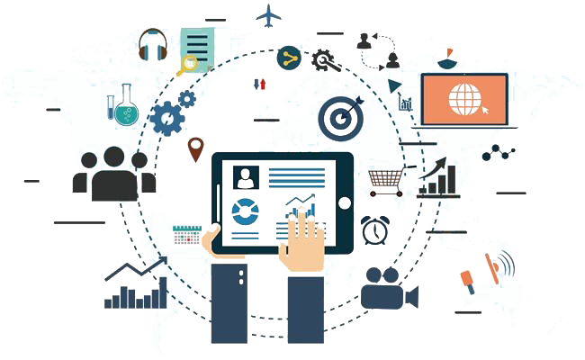

## Le domande

- Tra i vari argomenti dei post, qual è il dominante?
- Come interpreta una macchina i vari post all’interno di un blog?
- Quali sono le parole più digitate?
- Qual è il volto dell’ansia?

## Reddit non solo un forum

Reddit è un social news aggregator, un misto di piattaforma di discussione e distributore di link, diviso in forum, i cosiddetti subreddit. Gli utenti, i redditor, sono creatori di contenuti, consumatori e curatori. Utilizzando un sistema a punti composto da upvotes e downvotes, la comunità determina quali contenuti e discussioni sono importanti: questi verranno visualizzati nella parte superiore del feed. La piattaforma è in gran parte autogestita, i moderatori fungono da guardie del forum.

[figure not shown]

## Dataset

Un set di dati sui social media multidominio per identificare lo stress da cinque diverse categorie di comunità Reddit.

## Analisi Esplorativa

- Verifichiamo la grandezza del nostro dataset

```r
dim(myData)
```

```
## [1] 2838  116
```

- Scopriamo i nomi delle variabili

```r
names(myData)
```

```
##   [1] "subreddit"                "post_id"
##   [3] "sentence_range"           "text"
##   [5] "id"                       "label"
##   [7] "confidence"               "social_timestamp"
##   [9] "social_karma"             "syntax_ari"
##  [11] "lex_liwc_WC"              "lex_liwc_Analytic"
##  [13] "lex_liwc_Clout"           "lex_liwc_Authentic"
##  [15] "lex_liwc_Tone"            "lex_liwc_WPS"
##  [17] "lex_liwc_Sixltr"          "lex_liwc_Dic"
##  [19] "lex_liwc_function"        "lex_liwc_pronoun"
##  [21] "lex_liwc_ppron"           "lex_liwc_i"
##  [23] "lex_liwc_we"              "lex_liwc_you"
##  [25] "lex_liwc_shehe"           "lex_liwc_they"
##  [27] "lex_liwc_ipron"           "lex_liwc_article"
##  [29] "lex_liwc_prep"            "lex_liwc_auxverb"
```

[output cut: 43 more lines]

## Preparo il dataframe

```r
dataForGen = data.frame(myData[, c('subreddit')])
```

```r
head(dataForGen,100)
```

```
##     myData...c..subreddit...
## 1                       ptsd
## 2                 assistance
## 3                       ptsd
## 4              relationships
## 5           survivorsofabuse
## 6              relationships
## 7           domesticviolence
## 8                    anxiety
## 9              relationships
## 10                assistance
## 11                   anxiety
## 12                   anxiety
## 13                   anxiety
## 14                  homeless
```

[output cut: 86 more lines]

```r
colnames(dataForGen)
```

```
## [1] "myData...c..subreddit..."
```

## Analisi nello specifico

Tra i vari argomenti dei post, qual è il dominante?

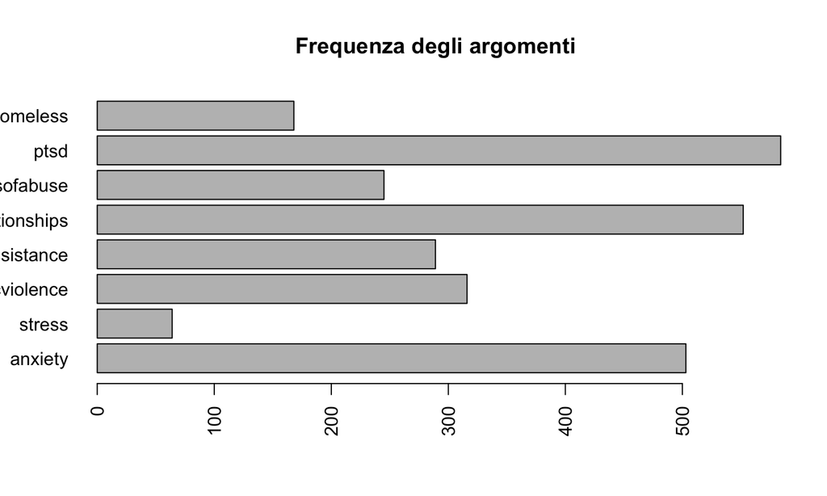

## Sentiment Analysis

Ed ora provo a rispondere alla seguente domanda Come interpreta una macchina i vari post all’interno di un blog?

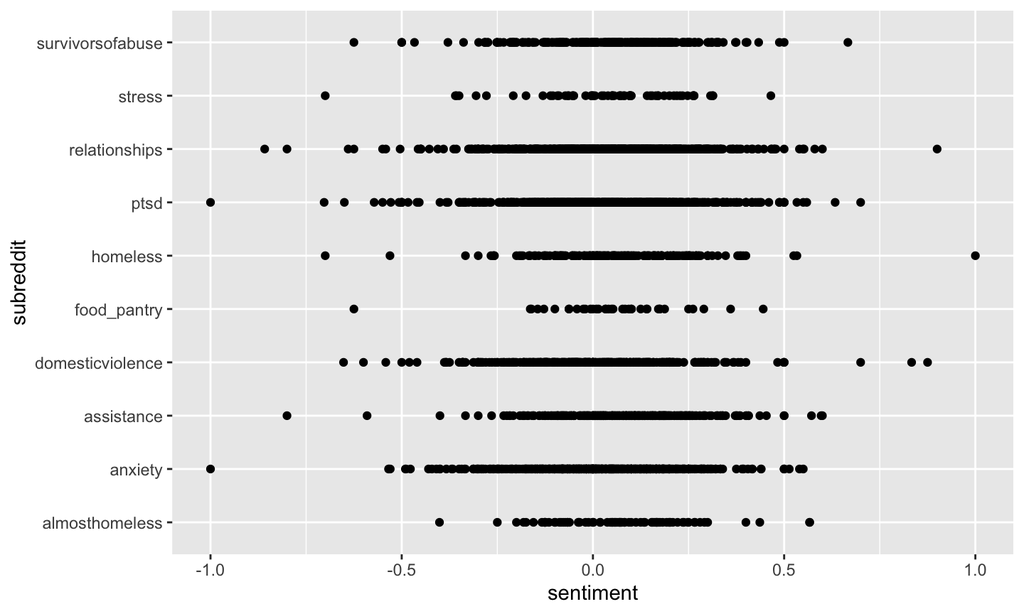

## Text mining

Quali sono le parole più digitate?

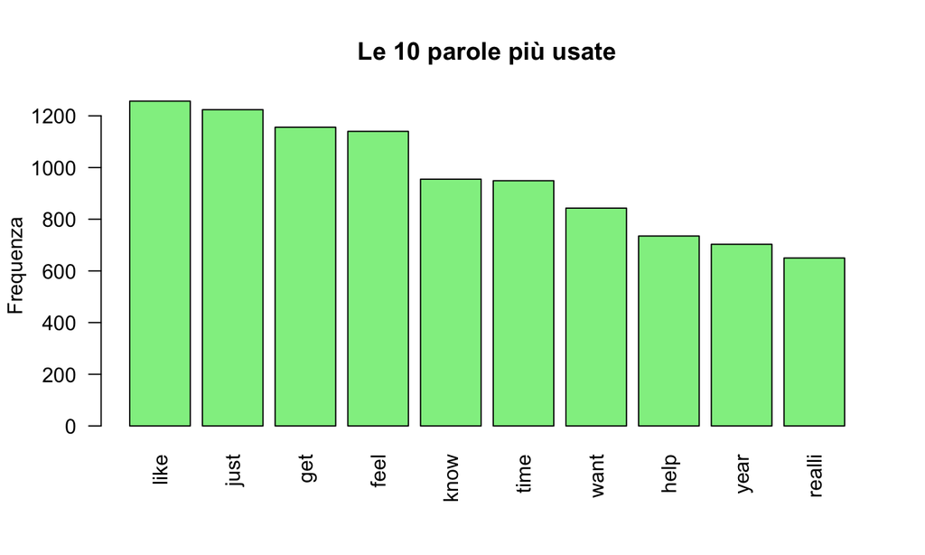

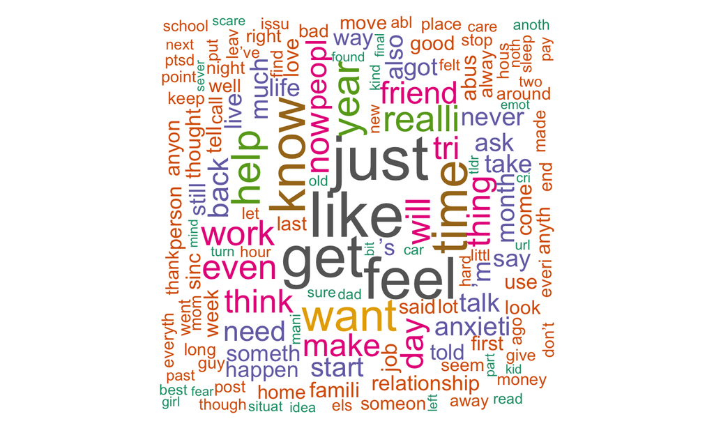

L’arte della comunicazione

- Sii onesto, non provare nemmeno a barare
- Sii efficace, massimizza l’entropia delle informazioni
- Sii artistico, rendilo bello

## Generative Art

##### E se volessimo rispondere alla domanda qui sotto ?

### Qual è il volto dell’ansia?

##### Potrebbe venirci in aiuto l’Arte Generativa

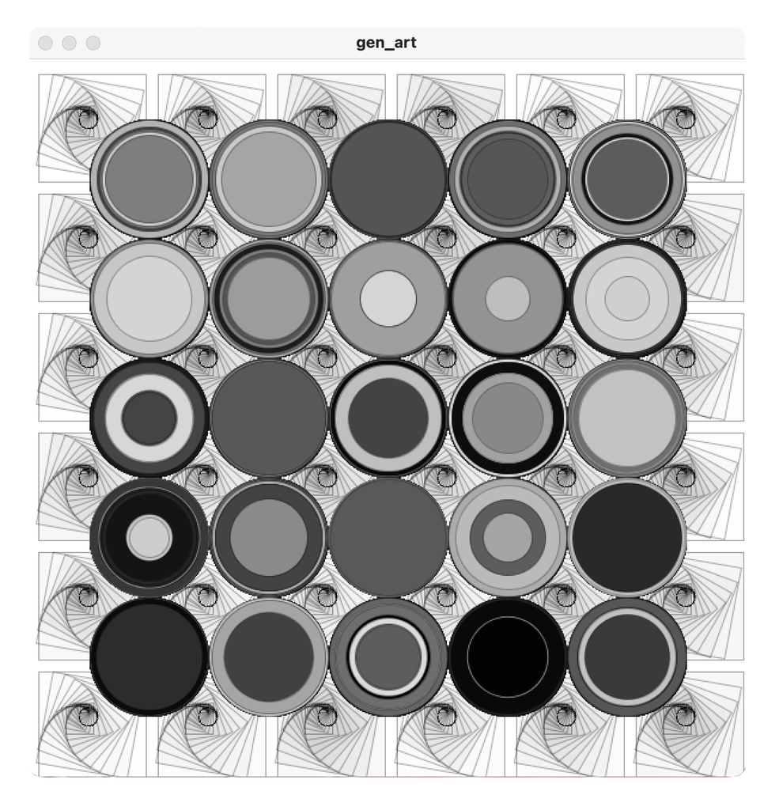

```r
#crea il dataset.csv da utilizzare con lo sketch in processing per generare un opera
write.csv(myData[, c('subreddit')],'gen_art/dataset_for_genart.csv')
```

Il file.csv viene passato ad uno sketch in processing che lo trasforma in un immagine.

## Note

- il dataset è stato scaricato da keggle ed è stato reso pubblico dall’utente con nome Ruchi Bhatia (https://www.kaggle.com/ruchi798/stress-analysis-in-social-media)
- il codice relativo alla generative art è stato parzialmente preso da un manuale di processing
- il resto delle nozioni sono state fornite dal corso di Fundamenti di Scienza dei Dati presso l’ateneo UNIUD

[figure not shown]